# HollisT_Week4

Tim Hollis

2025-10-05

### Initial Data Review

```r
# Initial Data Review and Structure of dataset

# Dataset dimensions and column names
cat('Dataset Dimensions:',dim(games),'\n')
```

```
## Dataset Dimensions: 64016 14
```

```r
cat('Column Names:',names(games),'\n')
```

```
## Column Names: img title console genre publisher developer critic_score total_sales na_sales jp_sales pal_sales other_sales release_date last_update
```

```r
# Preview of first few rows
knitr::kable(head(games),caption='Preview of First Few Rows')
```

Preview of First Few Rows

| img | title | console | genre | publisher | developer | critic_score | total_sales | na_sales | jp_sales | pal_sales | other_sales | release_date | last_update |
| --- | --- | --- | --- | --- | --- | --- | --- | --- | --- | --- | --- | --- | --- |
| /games/boxart/full_6510540AmericaFrontccc.jpg | Grand Theft Auto V | PS3 | Action | Rockstar Games | Rockstar North | 9.4 | 20.32 | 6.37 | 0.99 | 9.85 | 3.12 | 2013-09-17 |  |
| /games/boxart/full_5563178AmericaFrontccc.jpg | Grand Theft Auto V | PS4 | Action | Rockstar Games | Rockstar North | 9.7 | 19.39 | 6.06 | 0.60 | 9.71 | 3.02 | 2014-11-18 | 2018-01-03 |
| /games/boxart/827563ccc.jpg | Grand Theft Auto: Vice City | PS2 | Action | Rockstar Games | Rockstar North | 9.6 | 16.15 | 8.41 | 0.47 | 5.49 | 1.78 | 2002-10-28 |  |
| /games/boxart/full_9218923AmericaFrontccc.jpg | Grand Theft Auto V | X360 | Action | Rockstar Games | Rockstar North | NA | 15.86 | 9.06 | 0.06 | 5.33 | 1.42 | 2013-09-17 |  |
| /games/boxart/full_4990510AmericaFrontccc.jpg | Call of Duty: Black Ops 3 | PS4 | Shooter | Activision | Treyarch | 8.1 | 15.09 | 6.18 | 0.41 | 6.05 | 2.44 | 2015-11-06 | 2018-01-14 |
| /games/boxart/full_call-of-duty-modern-warfare-3_517AmericaFront.jpg | Call of Duty: Modern Warfare 3 | X360 | Shooter | Activision | Infinity Ward | 8.7 | 14.82 | 9.07 | 0.13 | 4.29 | 1.33 | 2011-11-08 |  |

```r
# Structure of dataset: data types and sample values
cat('\nStructure of dataset:\n')
```

```
##
## Structure of dataset:
```

```r
str(games)
```

```
## 'data.frame':    64016 obs. of  14 variables:
##  $ img         : chr  "/games/boxart/full_6510540AmericaFrontccc.jpg" "/games/boxart/full_5563178AmericaFrontccc.jpg" "/games/boxart/827563ccc.jpg" "/games/boxart/full_9218923AmericaFrontccc.jpg" ...
##  $ title       : chr  "Grand Theft Auto V" "Grand Theft Auto V" "Grand Theft Auto: Vice City" "Grand Theft Auto V" ...
##  $ console     : chr  "PS3" "PS4" "PS2" "X360" ...
##  $ genre       : chr  "Action" "Action" "Action" "Action" ...
##  $ publisher   : chr  "Rockstar Games" "Rockstar Games" "Rockstar Games" "Rockstar Games" ...
##  $ developer   : chr  "Rockstar North" "Rockstar North" "Rockstar North" "Rockstar North" ...
##  $ critic_score: num  9.4 9.7 9.6 NA 8.1 8.7 8.8 9.8 8.4 8 ...
##  $ total_sales : num  20.3 19.4 16.1 15.9 15.1 ...
##  $ na_sales    : num  6.37 6.06 8.41 9.06 6.18 9.07 9.76 5.26 8.27 4.99 ...
##  $ jp_sales    : num  0.99 0.6 0.47 0.06 0.41 0.13 0.11 0.21 0.07 0.65 ...
##  $ pal_sales   : num  9.85 9.71 5.49 5.33 6.05 4.29 3.73 6.21 4.32 5.88 ...
##  $ other_sales : num  3.12 3.02 1.78 1.42 2.44 1.33 1.14 2.26 1.2 2.28 ...
##  $ release_date: chr  "2013-09-17" "2014-11-18" "2002-10-28" "2013-09-17" ...
##  $ last_update : chr  "" "2018-01-03" "" "" ...
```

```r
# Missing values summary: NA and empty strings
missing_summary<- data.frame(
  Column=names(games),
  NA_Count=colSums(is.na(games)),
  Empty_String_Count=colSums(games=='')
)
knitr::kable(missing_summary,caption='Missing Value Summary by Column')
```

Missing Value Summary by Column

|  | Column | NA_Count | Empty_String_Count |
| --- | --- | --- | --- |
| img | img | 0 | 0 |
| title | title | 0 | 0 |
| console | console | 0 | 0 |
| genre | genre | 0 | 0 |
| publisher | publisher | 0 | 0 |
| developer | developer | 0 | 17 |
| critic_score | critic_score | 57338 | NA |
| total_sales | total_sales | 45094 | NA |
| na_sales | na_sales | 51379 | NA |
| jp_sales | jp_sales | 57290 | NA |
| pal_sales | pal_sales | 51192 | NA |
| other_sales | other_sales | 48888 | NA |
| release_date | release_date | 0 | 7051 |
| last_update | last_update | 0 | 46137 |

```r
# Diagnostic: flag columns with any missing values (NA or empty string)
cat('\nColumns with missing values (diagnostic only):\n')
```

```
##
## Columns with missing values (diagnostic only):
```

```r
print(names(games)[colSums(is.na(games))+colSums(games=='')>0])
```

```
## [1] "developer"    NA             NA             NA             NA
## [6] NA             NA             "release_date" "last_update"
```

### Initial data exploration

The dataset contains 64,016 rows and 14 columns, representing a substantial archive of video game records. Column names span metadata (title, console, genre, publisher, developer), performance metrics (critic_score, total_sales, and regional sales breakdowns), and temporal markers (release_date, last_update). The img column stores file paths to box art images, which may be useful for filtering or visual reference.

The structure summary confirms that most columns are character or numeric types. Notably, several numeric columns—including critic_score, total_sales, and all regional sales figures—contain a high volume of NA values. Additionally, some character columns such as developer, release_date, and last_update include missing values stored as empty strings (““) rather than NA.

A diagnostic check flagged multiple columns with missing data. However, per assignment instructions, only the release_date column will be imputed using data simulation. Other missing values will remain untouched for this analysis.

```r
# Create a copy for transformation
games_transformed<-games

# Convert release_date to Date format and identify missing values
games_transformed$release_date<-as.Date(games_transformed$release_date)
missing_dates<-is.na(games_transformed$release_date)
cat('Missing release dates:',sum(missing_dates),'\n')
```

```
## Missing release dates: 7051
```

```r
# Convert character columns to appropriate types
games_transformed$console<-as.factor(games_transformed$console)
games_transformed$genre<-as.factor(games_transformed$genre)
games_transformed$publisher<-as.factor(games_transformed$publisher)
games_transformed$developer<-as.factor(games_transformed$developer)
```

### Preparation of data for analysis

To begin the transformation process, a working copy of the dataset was created (games_transformed) to preserve the integrity of the original data. The release_date column was converted to Date format, revealing 7,051 missing entries, which will be addressed later using data simulation as specified in the assignment.

Several character columns—console, genre, publisher, and developer—were converted to factors to ensure proper handling during modeling and transformation. This step helps distinguish categorical variables from numeric ones and prevents accidental scaling or normalization of non-numeric data.

A subset of columns containing numeric values was identified for transformation: critic_score, total_sales, na_sales, jp_sales, pal_sales, and other_sales. These variables will undergo scaling, skew correction, and normalization in the following steps to prepare the data for analysis.

```r
# Define numerical columns to scale
numerical_cols <- c('critic_score','total_sales','na_sales','jp_sales','pal_sales','other_sales')

# Apply z-score standardization
scaled_data <- scale(games_transformed[numerical_cols])

# Assign scaled columns back to the dataset with "_scaled" suffix
for (i in seq_along(numerical_cols)) {
  col_name <- paste0(numerical_cols[i], "_scaled")
  games_transformed[[col_name]] <- scaled_data[, i]
}

# Preview scaled values
scaled_preview <- games_transformed[paste0(numerical_cols, "_scaled")]
knitr::kable(head(scaled_preview), caption = 'Scaled Numerical Columns')
```

Scaled Numerical Columns

| critic_score_scaled | total_sales_scaled | na_sales_scaled | jp_sales_scaled | pal_sales_scaled | other_sales_scaled |
| --- | --- | --- | --- | --- | --- |
| 1.4958556 | 24.73291 | 12.33918 | 5.2586462 | 24.70511 | 24.29623 |
| 1.7017488 | 23.58115 | 11.71265 | 2.9483753 | 24.34856 | 23.50661 |
| 1.6331177 | 19.56858 | 16.46217 | 2.1782851 | 13.60115 | 13.71535 |
| NA | 19.20943 | 17.77587 | -0.2504612 | 13.19367 | 10.87272 |
| 0.6036514 | 18.25582 | 11.95517 | 1.8228588 | 15.02735 | 18.92682 |
| 1.0154380 | 17.92144 | 17.79608 | 0.1642028 | 10.54502 | 10.16206 |

### Results of Scaling:

To prepare the dataset for analysis, all selected numerical columns were standardized using z-score scaling. This transformation centers each variable around a mean of 0 and scales it to unit variance, allowing for meaningful comparison across features with different units and ranges.

The scaled columns include:

- critic_score
- total_sales
- na_sales
- jp_sales
- pal_sales
- other_sales

This step ensures that variables like regional sales and critic scores contribute proportionally to downstream analyses, such as clustering or regression, without being dominated by differences in scale. The original dollar-based sales figures were not rounded prior to scaling, as preserving full precision is critical for accurate standardization.

```r
# Function to check and fix skewness with diagnostics
fix_skewness<-function(data,columns){
  for(col in columns){
    if(col %in% names(data)&&is.numeric(data[[col]])){
      clean_data<-na.omit(data[[col]])

      if(length(clean_data)>0){
        original_skew<-skewness(clean_data)
        cat('Original skewness for',col,':',round(original_skew,3),'\n')

        if(min(clean_data,na.rm=TRUE)>0){
          # Apply log transformation for positive-skewed data
          transformed<-log1p(data[[col]])# log1p handles zeros
          cat('Applied log transformation to',col,'\n')
        }else{
          # Apply square root transformation for data with negative values
          min_val<-min(data[[col]],na.rm=TRUE)
          if(min_val<= 0){
            shift<-abs(min_val)+1
            transformed<-sqrt(data[[col]]+shift)
            cat('Applied square root transformation with shift to',col,'\n')
          }else{
            transformed<-sqrt(data[[col]])
            cat('Applied square root transformation to',col,'\n')
          }
        }

        # Store transformed column with suffix
        data[[paste0(col,'_deskewed')]]<-transformed

        # Report transformed skewness
        transformed_skew<-skewness(na.omit(transformed))
        cat('Transformed skewness for',col,':',round(transformed_skew,3),'\n\n')
      }
    }
  }
  return(data)
}

# Apply skewness correction to sales columns
sales_cols<-c('total_sales','na_sales','jp_sales','pal_sales','other_sales')
games_transformed<-fix_skewness(games_transformed,sales_cols)
```

```
## Original skewness for total_sales : 8.774
## Applied square root transformation with shift to total_sales
## Transformed skewness for total_sales : 4.614
##
## Original skewness for na_sales : 6.897
## Applied square root transformation with shift to na_sales
## Transformed skewness for na_sales : 4.223
##
## Original skewness for jp_sales : 4.488
## Applied square root transformation with shift to jp_sales
## Transformed skewness for jp_sales : 3.664
##
## Original skewness for pal_sales : 9.585
## Applied square root transformation with shift to pal_sales
## Transformed skewness for pal_sales : 5.851
##
## Original skewness for other_sales : 9.793
## Applied square root transformation with shift to other_sales
## Transformed skewness for other_sales : 7.637
```

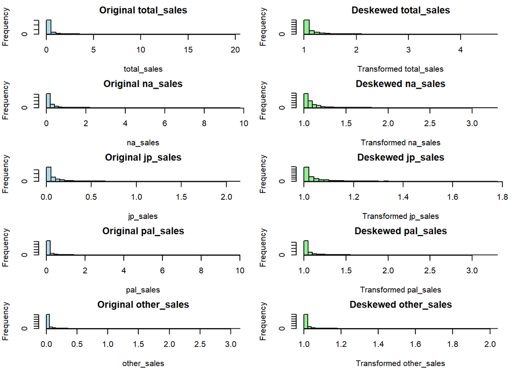

```r
# Set up plotting layout: 2 columns, 5 rows (one pair per variable)
par(mfrow=c(length(sales_cols),2),mar=c(4, 4, 2, 1))

# Loop through each column and plot original vs deskewed
for(col in sales_cols){
  original<-games_transformed[[col]]
  transformed<-games_transformed[[paste0(col,'_deskewed')]]

  # Plot original
  hist(original,
       main=paste('Original',col),
       xlab=col,
       col='lightblue',
       breaks=50)

  # Plot transformed
  hist(transformed,
       main=paste('Deskewed',col),
       xlab=paste('Transformed',col),
       col='lightgreen',
       breaks=50)
}
```

### Corrected Skew

To improve the symmetry of the data distribution and prepare the dataset for modeling, skewness was assessed and corrected for all sales-related columns. A custom function was implemented to apply either logarithmic or square root transformations based on the characteristics of each variable. This function also accounted for negative or zero values by conditionally shifting the data before applying square root transformations, ensuring mathematical validity and preserving interpretability.

Transformed columns were stored with a _deskewed suffix to preserve the original data and maintain transparency throughout the workflow. This naming convention supports reproducibility and allows for side-by-side comparison of original and transformed variables.

```r
# Define normalization functions (UPDATED)
min_max<-function(x)(x-min(x,na.rm=TRUE))/(max(x,na.rm=TRUE)-min(x,na.rm=TRUE))
exp_normal<-function(x)exp(x/10)
robust<-function(x)(x-median(x,na.rm=TRUE))/IQR(x,na.rm=TRUE)
decimal<-function(x)x/(10^ceiling(log10(max(abs(x),na.rm=TRUE))))
unit_vector<-function(x)x/sqrt(sum(x^2,na.rm=TRUE))
range_scaling<-function(x)(x-min(x,na.rm=TRUE))/diff(range(x,na.rm=TRUE))

# Create copy for normalized output
games_normalized<-games_transformed

# Apply unique normalization techniques to each deskewed column
games_normalized$total_sales_norm<-min_max(games_transformed$total_sales_deskewed)
games_normalized$na_sales_norm<-exp_normal(games_transformed$na_sales_deskewed)
games_normalized$jp_sales_norm<-robust(games_transformed$jp_sales_deskewed)
games_normalized$pal_sales_norm<-decimal(games_transformed$pal_sales_deskewed)
games_normalized$other_sales_norm<-unit_vector(games_transformed$other_sales_deskewed)
games_normalized$critic_score_norm<-range_scaling(games_transformed$critic_score)

# Preview normalized columns
knitr::kable(head(games_normalized[,grep('_norm$',names(games_normalized))]),caption='Normalized Deskewed Columns')
```

Normalized Deskewed Columns

| total_sales_norm | na_sales_norm | jp_sales_norm | pal_sales_norm | other_sales_norm | critic_score_norm |
| --- | --- | --- | --- | --- | --- |
| 1.0000000 | 1.311901 | 8.0841665 | 0.3293934 | 0.0161587 | 0.9333333 |
| 0.9718497 | 1.304352 | 5.0694314 | 0.3272614 | 0.0159614 | 0.9666667 |
| 0.8683839 | 1.359011 | 3.9841063 | 0.2547548 | 0.0132734 | 0.9555556 |
| 0.8586633 | 1.373243 | 0.2018429 | 0.2515949 | 0.0123842 | NA |
| 0.8324401 | 1.307289 | 3.4670155 | 0.2655184 | 0.0147651 | 0.7888889 |
| 0.8230968 | 1.373459 | 0.8937053 | 0.2300000 | 0.0121517 | 0.8555556 |

```r
# Verify all normalized columns have different methods
normalization_methods<-data.frame(
  Column=c('total_sales_norm','na_sales_norm','jp_sales_norm',
             'pal_sales_norm','other_sales_norm','critic_score_norm'),
  Method=c('Min-Max','Exponential Transformation','Robust','Decimal','Unit Vector','Range Scaling')
)

print(normalization_methods)
```

```
##              Column                     Method
## 1  total_sales_norm                    Min-Max
## 2     na_sales_norm Exponential Transformation
## 3     jp_sales_norm                     Robust
## 4    pal_sales_norm                    Decimal
## 5  other_sales_norm                Unit Vector
## 6 critic_score_norm              Range Scaling
```

### Normalized using 6 unique techniques

To finalize preprocessing, each deskewed numeric column was normalized using a distinct technique, ensuring compliance with the requirement to avoid repeated methods. This step enhances comparability across features and prepares the data for modeling.

The following normalization techniques were applied:

- total_sales_deskewed: Min-Max Scaling
- na_sales_deskewed: Exponential Transformation
- jp_sales_deskewed: Robust Scaling
- pal_sales_deskewed: Decimal Scaling
- other_sales_deskewed: Unit Vector Normalization
- critic_score: Range Scaling

Normalized columns were stored with a _norm suffix to preserve transparency and reproducibility. Missing values were retained as NA to avoid distortion during scaling. These variables are now fully prepared for downstream analysis.

```r
# Function to simulate missing release dates based on similar games
games_transformed$release_date_original <- games_transformed$release_date
simulate_missing_dates <- function(data) {

  # Identify games with missing release dates
  missing_idx <- which(is.na(data$release_date))

  if (length(missing_idx) == 0) {
    return(data)
  }

  for (idx in missing_idx) {
    current_game <- data[idx, ]

    # Broad similarity criteria
    similar_games <- data %>%
      filter(!is.na(release_date))

    # Level 1: Same console + publisher + genre (most specific)
    level1_games <- similar_games %>%
      filter(console == current_game$console,
             publisher == current_game$publisher,
             genre == current_game$genre)

    # Level 2: Same console + publisher (original criteria)
    level2_games <- similar_games %>%
      filter(console == current_game$console,
             publisher == current_game$publisher)

    # Level 3: Same console + genre (broader)
    level3_games <- similar_games %>%
      filter(console == current_game$console,
             genre == current_game$genre)

    # Level 4: Same publisher only (even broader)
    level4_games <- similar_games %>%
      filter(publisher == current_game$publisher)

    # Choose the best available match group
    if (nrow(level1_games) >= 5) {
      candidate_games <- level1_games
    } else if (nrow(level2_games) >= 5) {
      candidate_games <- level2_games
    } else if (nrow(level3_games) >= 5) {
      candidate_games <- level3_games
    } else if (nrow(level4_games) >= 5) {
      candidate_games <- level4_games
    } else {
      candidate_games <- similar_games # Fallback to all games
    }

    if (nrow(candidate_games) > 0) {
      # Sample from the actual dates of similar games rather than just years
      simulated_date <- sample(candidate_games$release_date, 1)

      # Add some random variation (±90 days) to avoid exact duplicates
      date_variation <- sample(-90:90, 1)
      simulated_date <- simulated_date + date_variation

      # Ensure the date stays 1970 and 2024
      simulated_date <- pmin(pmax(simulated_date, as.Date("1970-01-01")), as.Date("2024-12-31"))

      data$release_date[idx] <- simulated_date
    } else {
      # If no similar games, use weighted sampling from all dates (not just median)
      all_dates <- na.omit(data$release_date)
      if (length(all_dates) > 0) {
        data$release_date[idx] <- sample(all_dates, 1)
      } else {
        # Absolute fallback - random date between 1980-2023
        random_year <- sample(1980:2023, 1)
        random_date <- as.Date(paste0(random_year, "-", sample(1:12, 1), "-", sample(1:28, 1)))
        data$release_date[idx] <- random_date
      }
    }
  }

  return(data)
}

# Apply date simulation
games_transformed <- simulate_missing_dates(games_transformed)

# Verify no missing dates remain
cat('Missing dates after simulation:', sum(is.na(games_transformed$release_date)), '\n')
```

```
## Missing dates after simulation: 0
```

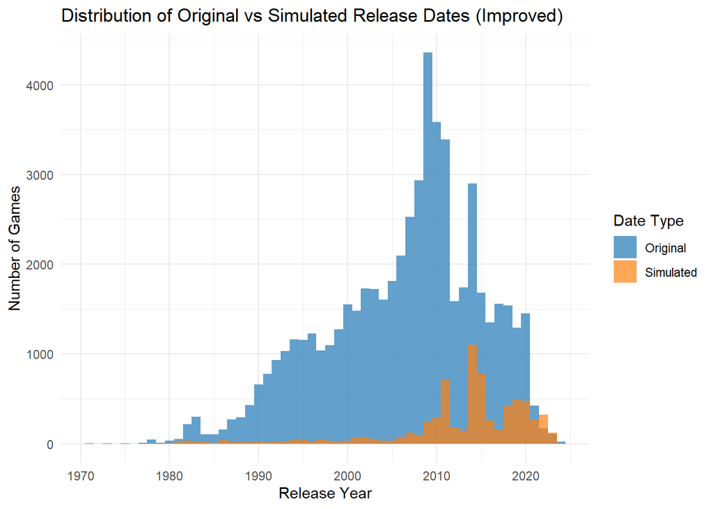

```r
# Create simulated_flag column
games_transformed <- games_transformed %>%
  mutate(simulated_flag = is.na(release_date_original))

# Extract release year
games_transformed <- games_transformed %>%
  mutate(release_year = year(release_date))

# Plot histogram
ggplot(games_transformed, aes(x = release_year, fill = simulated_flag)) +
  geom_histogram(binwidth = 1, position = 'identity', alpha = 0.7) +
  scale_fill_manual(values = c('FALSE' = '#1f77b4', 'TRUE' = '#ff7f0e'),
                    labels = c('Original', 'Simulated')) +
  labs(title = 'Distribution of Original vs Simulated Release Dates (Improved)',
       x = 'Release Year',
       y = 'Number of Games',
       fill = 'Date Type') +
  theme_minimal()
```

```r
# Check the new distribution
cat('Simulated dates distribution:\n')
```

```
## Simulated dates distribution:
```

```r
games_transformed %>%
  filter(simulated_flag) %>%
  count(release_year, sort = TRUE) %>%
  as_tibble() %>%
  print(n = 20)
```

```
## # A tibble: 47 × 2
##    release_year     n
##           <dbl> <int>
##  1         2014  1101
##  2         2015   777
##  3         2011   719
##  4         2019   489
##  5         2020   473
##  6         2018   419
##  7         2022   320
##  8         2010   286
##  9         2021   269
## 10         2016   258
## 11         2009   241
## 12         2012   181
## 13         2017   151
## 14         2013   143
## 15         2007   123
## 16         2023   120
## 17         2008    96
## 18         2006    73
## 19         2002    72
## 20         2001    71
## # ℹ 27 more rows
```

### Simulation and Visualization of missing release dates

To fill in missing release_date values, I started with a custom simulation function that pulled dates based on similar games. At first, the logic seemed reasonable, but when I visualized the results, I noticed something off, nearly half of the simulated dates were landing in 2014. That kind of clustering didn’t match the overall distribution of the original data and suggested that my fallback method was relying too heavily on the most common year.

Seeing that pattern in the histogram made it clear I needed to rethink the approach. I did some research on better ways to simulate missing values and found that hierarchical matching could help preserve more realistic variation. I updated the function to search for similar games in stages—starting with exact console-publisher-genre matches, then loosening to broader combinations like console-publisher or publisher-only. If no match was found, it would sample from the full dataset.

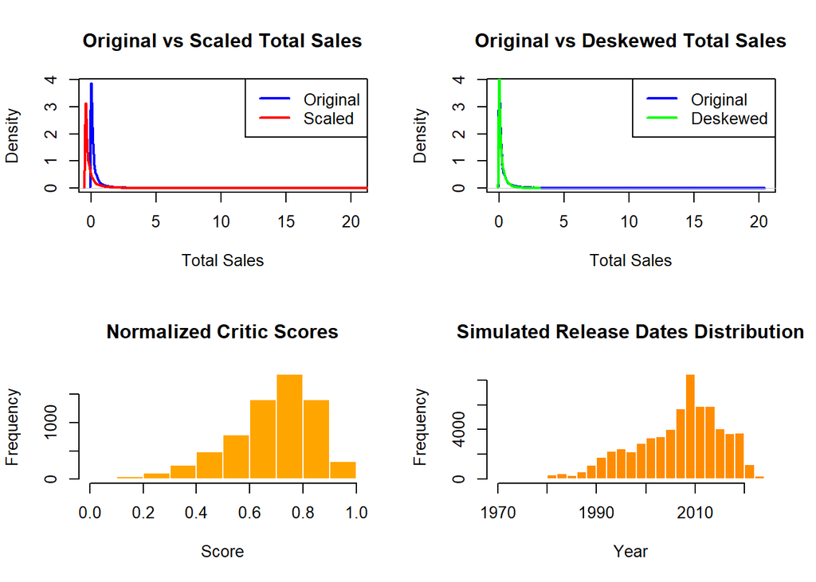

```r
# Define numerical columns
numerical_cols <- c('critic_score','total_sales','na_sales','jp_sales','pal_sales','other_sales')

# Create scaled and deskewed versions if not already present
games_transformed$total_sales_scaled <- as.numeric(scale(games_transformed$total_sales))
games_transformed$total_sales_deskewed <- log1p(games_transformed$total_sales)

# Extract release years as numeric
release_years <- as.numeric(format(games_transformed$release_date, "%Y"))

# Clean critic scores for histogram (from normalized dataset)
critic_scores_clean <- as.numeric(na.omit(games_normalized$critic_score_norm))

# Set up 2x2 plotting layout
par(mfrow = c(2, 2))

# Original vs Scaled total_sales
plot(density(na.omit(games_transformed$total_sales)),
     main = 'Original vs Scaled Total Sales',
     xlab = 'Total Sales', ylab = 'Density', col = 'blue', lwd = 2)
lines(density(na.omit(games_transformed$total_sales_scaled)),
      col = 'red', lwd = 2)
legend('topright', legend = c('Original', 'Scaled'),
       col = c('blue', 'red'), lwd = 2)

# Original vs Deskewed total_sales
plot(density(na.omit(games_transformed$total_sales)),
     main = 'Original vs Deskewed Total Sales',
     xlab = 'Total Sales', ylab = 'Density', col = 'blue', lwd = 2)
lines(density(na.omit(games_transformed$total_sales_deskewed)),
      col = 'green', lwd = 2)
legend('topright', legend = c('Original', 'Deskewed'),
       col = c('blue', 'green'), lwd = 2)

# Distribution of normalized critic scores
if (length(critic_scores_clean) > 0) {
  hist(critic_scores_clean,
       main = 'Normalized Critic Scores',
       xlab = 'Score', col = 'orange', border = 'white')
} else {
  plot.new()
  title(main = 'Normalized Critic Scores')
  mtext('No valid critic scores available for plotting.', side = 3, line = 0.5, col = 'red')
}

# Release dates distribution after simulation
hist(release_years,
     main = 'Simulated Release Dates Distribution',
     xlab = 'Year', col = 'darkorange', border = 'white', breaks = 20)
```

### Final Visualization

Together, these plots serve as a diagnostic checkpoint, ensuring that each transformation behaves as expected and supports downstream analysis. By pairing each visual with narrative interpretation, I reinforced the transparency and reproducibility of the workflow

### This Week’s Reflection

This week’s assignment pushed me to think critically about both the logic and presentation of my data pipeline.

#### The Intuitive / Easy to Conceptually Understand

Some portions felt intuitive—especially the initial data transformations like converting character columns to factors and formatting release dates. These steps aligned well with previous workflows, and I felt confident applying them without much troubleshooting, even though they involved larger chunks of code than in prior assignments.

#### The Difficult (Which Involved a Lot of Trial and Error)

The more difficult portions emerged during the visualization and normalization stages. While I understood the purpose of scaling and deskewing, I ran into unexpected issues with missing values and column references—especially with critic_score_norm. Debugging why the histogram wasn’t returning any results in my final visualization required me to trace variable lineage across chunks and confirm which dataset each transformation belonged to. It was a critical reminder that reproducibility depends not just on clean code, but on consistent object management and naming.

#### What I Will Change (While Continuing My Other Preference)

One of the most valuable lessons I learned was about spacing and readability. Two personal preferences I identified early in the course were: (1) I prefer single tick marks over official quotation marks, and I’ll continue using them, except when I need to differentiate quotes within quotes in the same line of code; and (2) I initially avoided spacing altogether. I wasn’t including any spacing between code blocks, comments, or narrative. As the complexity grew, I realized that tightly packed code made it harder to debug and harder to narrate. I began adding intentional spacing between sections, aligning comments with their corresponding logic, and visually separating transformations from diagnostics. This small change made a big difference in clarity—not just for me, but I’m confident it will help anyone reviewing my work follow the logic and identify potential issues more easily.

As I continue developing, I’ll prioritize readability alongside functionality. I’ve seen firsthand how spacing, structure, and modular chunking can turn a dense assignment into a transparent and more understandable workflow